# CogSci Experiment 1 (single question, same screen)

Karen Gu

[Link to experiment](https://www.mit.edu/~karengu/elephants_expt1_single_samescreen/elephants/experiments/elephants-11.html)

## elephants-3, single question, same screen

Experiment 1 for CogSci 2019 (Elephants-3i), with a single question (Africa only), all info presented on the same screen

## Subject Information

| workerid | language | enjoyment | age | gender | problems | comments |
| --- | --- | --- | --- | --- | --- | --- |
| e59126bbd20fecb9e8b9c1394003da1f | English | 1 | 34 | Male | No problems. |  |
| ca04e9ed63dcb79ab53989aa12e81ef9 | English | 0 | 34 | Other | No, everything worked fine | None, thanks for fairly compensating workers! |
| 1cef02fd0b84c505b54f5fe4b15f00e6 | English | 0 | 37 | Male | no |  |
| 6ee05949db82f1b2a7d8703345b9c46c | United States | 0 | 34 | Male | none |  |
| fc3d0f6ad945a9c3bb5399d9e7aa2446 | english | 1 | 28 | Female | nil | nice and useful |
| 5934c04d289e3ac41262861d7af21a0f | English | 1 | 33 | Female |  |  |
| ed3a50577e6fd3d21cf3a3e968f09063 | English | 1 | 35 | Male |  |  |
| af982cbad1f9f48e846937073a238216 | english | 0 | 26 | Male | none | none |
| 32daf4698f607d156c871c34d612e89e | English | 1 | 41 | Female | no |  |
| 0f287385531bd54a08600696e7ce0454 | english | 0 | 34 | Male | No issues. |  |
| 0541a894a97a50907ffe62a487cec0a1 | English | 1 | 28 | Male | no | good |
| d3defa7a7e9b94696dd42b4ec7f30b2e | English | 0 | 46 | Female | None | None |
| 6e13724f41911dde2e2f24c0c755dff3 | english | 1 | 41 | Female | no |  |
| 73ef4537256069ca142e7a63decb3be5 | English | -1 | 31 | Male | No. |  |
| 6673d8b0953a7ec746c175c08679181b | english | 0 | 38 | Male | none | none |
| b95a45b5d49a5d95a0cb9f8af3089b40 | English | 1 | 51 | Female | No |  |
| db8dd3c8f0ddf15708630e330d1bb030 | English | 1 | 43 | Female | None. |  |
| 195a61e811ee6a431326a8b20674626d | English | 0 | 26 | Male | no |  |
| c52074473e55c1cdb563d7185130eed2 | English | 0 | 52 | Male | None | None |
| edb275de6d287301a22fb9b844fdba73 | English | 0 | 49 | Female |  |  |
| f9ab1041e0a0b182264639dad9f125f3 | English | 1 | 26 | Female | No, their was no problems | none |
| cb76abad72df18098c8593513610c5d2 | English | 1 | 31 | Female | No. | Thank you! |
| 80d5f4bb6b2fa799cc458fd16cd86486 | english | 1 | 47 | Female | no issues, everything ran smoothly |  |
| ba8a3e8a9d70b2faaa9cbaaf1fb74588 | English | 1 | 40 | Male | no | Thank you for not asking about coronavirus |
| e16a46bb97fdc690c5caf7229c1e2ea3 | English | 1 | 26 | Male | No |  |
| 4f625042d19af8fae683ac55944291d7 | English | 1 | 22 | Female | no |  |
| 0d00290f86c1fdd44430baab44cdf892 | English | 1 | 28 | Male | None at all | I hope my input helps! Thank you! |

## Attention Checks

### Slider Practice

- dogs bark (coded as correct if x > 0.5)
- birds are male (coded as correct if 0.25 < x < 0.75)
- cats get cancer (coded as correct if x < 0.75) [being generous with this one]
- lions lay eggs (coded as correct if x < 0.10)

| n_correct | n |
| --- | --- |
| 1 | 1 |
| 3 | 1 |
| 4 | 25 |

| property | n_correct |
| --- | --- |
| birds are male | 26 |
| cats get cancer | 26 |
| dogs bark | 27 |
| lions lay eggs | 25 |

### Memory Check

After the story, participants select statements they recall learning from a list of 10 generic statements about novel animals (5 true, 5 distractor). They are also asked to explain what they did in the experiment.

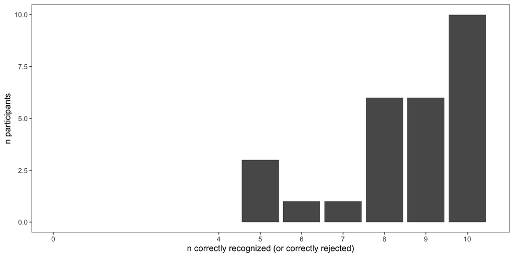

### Slider Practice and Memory Check

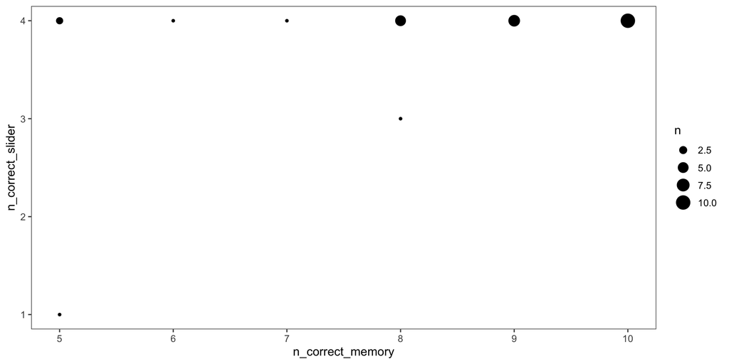

### Explanations of Task

After the story, participants are also asked to explain generally what they did in the experiment.

| workerid | n_slider_correct | n_memory_correct | explanation |
| --- | --- | --- | --- |
| e59126bbd20fecb9e8b9c1394003da1f | 4 | 8 | Set a value of what percentage of a type of alien have or do something |
| ca04e9ed63dcb79ab53989aa12e81ef9 | 4 | 10 | read a short passage and then used a slider to indicate whether the subject in question did X behavior/had Y characteristic a certain percentage of the time. |
| 1cef02fd0b84c505b54f5fe4b15f00e6 | 4 | 10 | I made probability judgements due to phrases |
| 6ee05949db82f1b2a7d8703345b9c46c | 4 | 9 | learn about creatures on alien planets and decide what percentage of them have a characteristics based on the facts stated. |
| fc3d0f6ad945a9c3bb5399d9e7aa2446 | 1 | 5 | nice and usefull |
| 5934c04d289e3ac41262861d7af21a0f | 4 | 6 | we read short passages about an alien world called Dax, and answered questions about each passage |
| ed3a50577e6fd3d21cf3a3e968f09063 | 4 | 9 | I read paragraphs of aliens and their environment and determined whether the statement provided was correct based on the wording and details of the paragraph. |
| af982cbad1f9f48e846937073a238216 | 4 | 8 | reading comprehension. |
| 32daf4698f607d156c871c34d612e89e | 4 | 7 | That was tough with all those hard names. I had to try and figure out the percentage I thought the story described. |
| 0f287385531bd54a08600696e7ce0454 | 4 | 9 | Read passages about aliens and answered a question about each of the passages. |
| 0541a894a97a50907ffe62a487cec0a1 | 4 | 5 | Aliens language |
| d3defa7a7e9b94696dd42b4ec7f30b2e | 4 | 10 | I read information on different aliens and animals and then make guesses as to the percentage of those animals or aliens did things in response to the questions. |
| 6e13724f41911dde2e2f24c0c755dff3 | 4 | 9 | read sentences and select how true a statement is |
| 73ef4537256069ca142e7a63decb3be5 | 4 | 9 | Rate the likelihood that a given statement is true or false on a scale out of 100%. |
| 6673d8b0953a7ec746c175c08679181b | 4 | 10 | I read each paragraph. Then, I read the question. Finally, I went back through the paragraph to find that specific answer and confirm that I was selecting the right answer. |
| b95a45b5d49a5d95a0cb9f8af3089b40 | 4 | 5 | Read about animals and aliens on a far-away planet, and was asked some questions about them. |
| db8dd3c8f0ddf15708630e330d1bb030 | 4 | 8 | I paid attention to words like all or some to get an idea of the percentages. |
| 195a61e811ee6a431326a8b20674626d | 4 | 8 | I read about different aliens. |
| c52074473e55c1cdb563d7185130eed2 | 4 | 10 | A statement was given and then we had to answer a question based on that statement giving a percentage answer. |
| edb275de6d287301a22fb9b844fdba73 | 4 | 8 | I marked on a slider what number seemed to apply to a statement according to a short passage. |
| f9ab1041e0a0b182264639dad9f125f3 | 4 | 10 | Well i read a either what animals did or aliens did then i had to choose what percentage that the animal or aliens did. |
| cb76abad72df18098c8593513610c5d2 | 4 | 10 | Read about aliens on an alien planet and answered questions about percentages of their habits and features based on the reading. |
| 80d5f4bb6b2fa799cc458fd16cd86486 | 4 | 10 | tried to make logical estimates based on provided information |
| ba8a3e8a9d70b2faaa9cbaaf1fb74588 | 4 | 10 | Select percentage of animals that did a particular thing/fact. |
| e16a46bb97fdc690c5caf7229c1e2ea3 | 4 | 9 | I read passages and answer questions about the quantity of animals that have certain traits or behaviors. |
| 4f625042d19af8fae683ac55944291d7 | 4 | 10 | read about wierd alien creatures with weird names |
| 0d00290f86c1fdd44430baab44cdf892 | 3 | 8 | I was asked to determine how true I thought a fact was about an alien race based upon the text that I read. |

## Participants

### Included/Excluded Subject Numbers

Removing participants who got fewer than 7 correct on memory check and didn’t get all 4 sliders. (Participants with bad explanations usually fell into one of these other groups.)

| memory_fail | slider_fail | n |
| --- | --- | --- |
| FALSE | FALSE | 22 |
| FALSE | TRUE | 1 |
| TRUE | FALSE | 3 |
| TRUE | TRUE | 1 |

### Prevalence Estimates by Participant

Histogram of all of a single participant’s prevalence estimates, collapsed across trials and color coded for the number of correct responses on the memory check. * fill = number of correct responses on the memory check (out of 10) * facet = participants

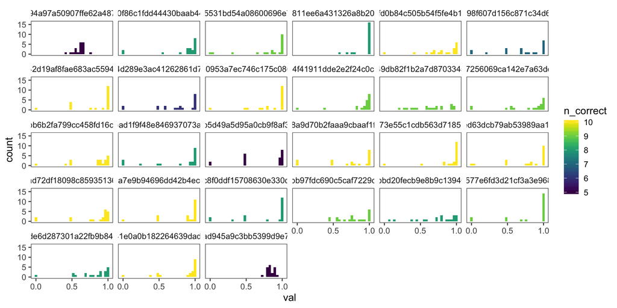

## Filler Trials

These used quantifiers (and thus we have strong idea about literal meaning).

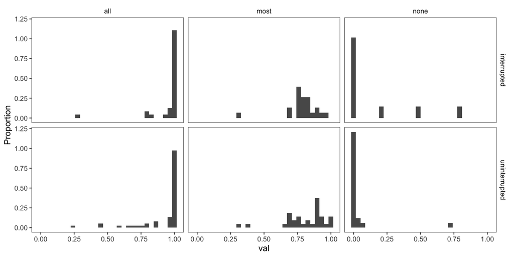

## Critical Trials (collapsed across item)

## Histograms of Prevalence Estimates by Condition (collapsed across item)

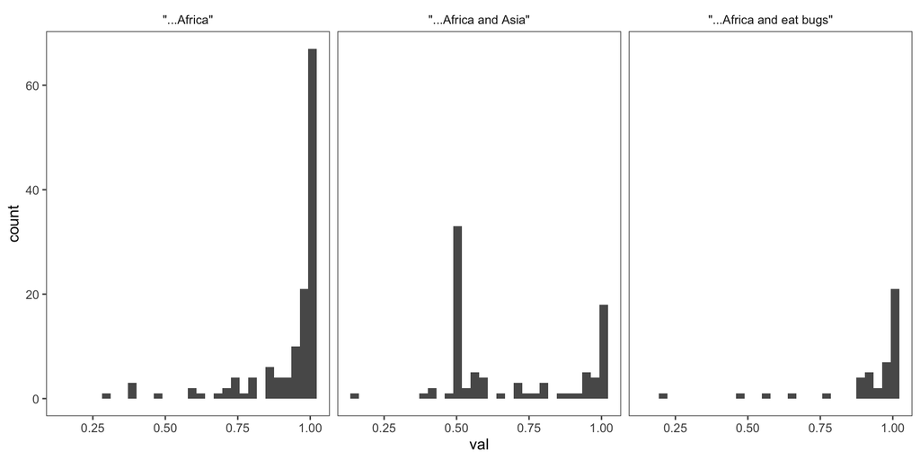

### Bootstrapped 95% Confidence Intervals (collapsed across item)

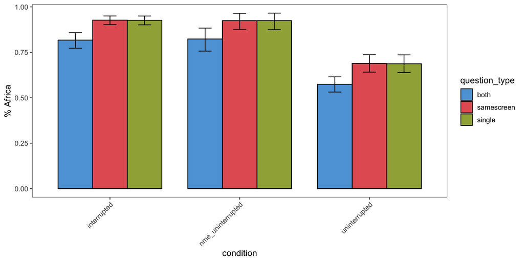

### Pirate Plots (collapsed across item)

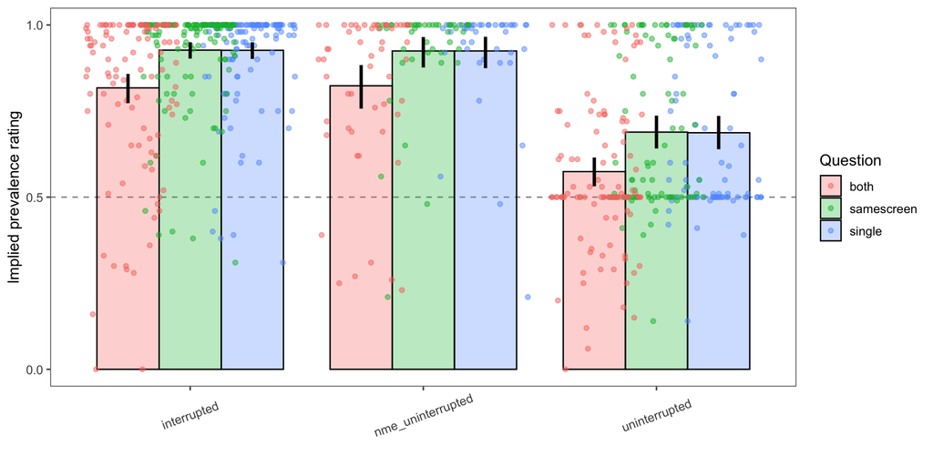

### Ridge Plots

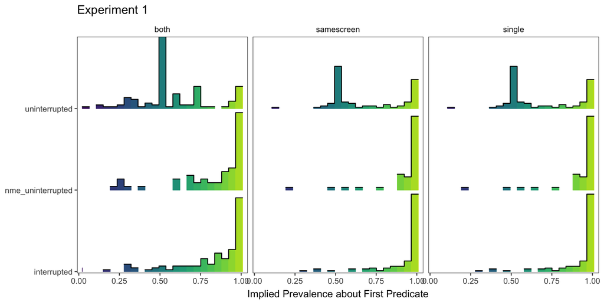

### Stats

#### Regression

```
## Linear mixed model fit by REML ['lmerMod']
## Formula: val ~ condition + (1 | workerid) + (1 | predicate_1)
##    Data: model.data
##
## REML criterion at convergence: -455.9
##
## Scaled residuals:
##     Min      1Q  Median      3Q     Max
## -3.7167 -0.5663  0.1487  0.5419  2.7497
##
## Random effects:
##  Groups      Name        Variance Std.Dev.
##  workerid    (Intercept) 0.016774 0.12951
##  predicate_1 (Intercept) 0.000948 0.03079
##  Residual                0.027599 0.16613
## Number of obs: 798, groups:  workerid, 49; predicate_1, 16
##
## Fixed effects:
##                             Estimate Std. Error t value
## (Intercept)                 0.868860   0.022058  39.390
## conditionnme_uninterrupted  0.001179   0.016552   0.071
## conditionuninterrupted     -0.241275   0.013370 -18.046
##
## Correlation of Fixed Effects:
##             (Intr) cndtn_
## cndtnnm_nnt -0.217
## cndtnnntrrp -0.271  0.357
```